# Primer Parcial - Modelo A

Análisis de Datos

2022-10-27

## Introducción

El paquete `nycflights13` contiene información sobre todos los vuelos que partieron de la ciudad de Nueva York (NYC) de los aeropuertos Aeropuerto Internacional Libertad de Newark (EWR), Aeropuerto Internacional John F. Kennedy (JFK) y Aeropuerto Internacional de La Guardia LGA en 2013. Los datos se encuentran en el dataframe `flights`.

Ejecuta el siguiente bloque de código para cargar las librerías necesarias para el examen, y crear los datos `flights_small`, que son una versión reducida del conjunto de datos `flights` con únicamente 10000 vuelos. Para el resto del examen, utiliza los datos `flights_small`.

```r
library(tidyverse)
library(nycflights13)

set.seed(13)
flights_small <- flights %>% sample_n(10000)
```

Alternativamente, si lo anterior no te funciona, puedes descargar los datos `flights_small.csv` de Canvas y colocarlos en la carpeta donde estés ejecutando R. Una vez hayas hecho esto, puedes leerlos usando

```r
flights_small <- read_csv("flights_small.csv")
```

Esta base de datos contiene información acerca de 19 variables. No obstante, para este examen únicamente utilizaremos las siguientes:

- `hour`: hora del vuelo.
- `month`: mes del vuelo.
- `origin`: aeropuerto de origen.
- `dest`: aeropuerto de destino.
- `air_time` : tiempo en el aire, en minutos.
- `carrier`: aerolínea
- `dep_delay`: retraso en despegue (en minutos).
- `arr_delay`: retraso en la llegada (en minutos).

## Ejercicio 1 (1 pts)

¿Cuáles fueron las tres horas del día en las que existen menos vuelos? Haz una tabla en la que aparezca **únicamente** las **tres** horas con menos vuelos en orden **ascendente** de número de vuelos y muestre también la cantidad de vuelos que despegaron durante esas horas. (Ten en cuenta que las horas están escritas en formato de 24 horas, por ejemplo, `hour` = 14 son las 2 p. m.).

```r
flights_small %>%
  count(hour) %>%
  arrange(n) %>%
  slice(1:3)
```

```
## # A tibble: 3 × 2
##    hour     n
##   <dbl> <int>
## 1     1     1
## 2    23    48
## 3     5    80
```

## Ejercicio 2 (2 pts)

Para los vuelos que partieron de los aeropuertos de Nueva York en 2013, ¿cuáles son las cuatro combinaciones de aeropuertos de origen y destino más comunes? Presenta los resultados en términos de la proporción sobre el total de vuelos que aparecen en los datos. Para las cuatro combinaciones más comunes, muestra **únicamente** el aeropuerto de origen, el aeropuerto de destino y la proporción correspondiente en su tabla.

**Aclaración**: Si entre los aeropuertos X e Y hubiese 3000 vuelos en los datos, la proporción que se pide es 0.3, ya que los datos tienen 10000 registros en total.

```r
flights_small %>%
  count(origin, dest) %>%
  mutate(prop = n / sum(n)) %>%
  arrange(desc(prop)) %>%
  slice(1:4) %>%
  select(-n)
```

```
## # A tibble: 4 × 3
##   origin dest    prop
##   <chr>  <chr>  <dbl>
## 1 JFK    LAX   0.0355
## 2 LGA    ATL   0.0312
## 3 LGA    ORD   0.0255
## 4 JFK    SFO   0.0228
```

## Ejercicio 3 (2 pts)

Considere solo los vuelos que **no** tienen un na en la información de tiempo en el aire: ¿Los vuelos a qué aeropuerto tienen la mediana de tiempo en el aire más alta? ¿Cuańto vale esta mediana? ¿Es esperable este resultado?

*Pista: si no conoces las siglas del aeropuerto resultante, puedes usar internet para determinarlas.

```r
flights_small %>%
  filter(!is.na(air_time)) %>%
  group_by(dest) %>%
  summarise(med_air_time = median(air_time)) %>%
  arrange(desc(med_air_time)) %>%
  slice(1)
```

```
## # A tibble: 1 × 2
##   dest  med_air_time
##   <chr>        <dbl>
## 1 HNL            610
```

## Ejercicio 4 (5 pts)

Recrea el gráfico del pdf utilizando los datos de `flights_small`. Fíjate en todos los detalles. Además, describe el propósito de esta visualización y extrae alguna conclusión.

- Pista 1: la visualización usa una variable llamada `dep_status`, que no está incluida en los datos `flights_small`. Tendrá que crear `dep_status` tú mismo mismo. Se trata de una variable categórica que es igual a “ontime” cuando `dep_delay` <= 0 y “delayed” cuando `dep_delay` > 0.*
- Pista 2: AA y B6 son dos aerolíneas. JFK y LGA son los aeropuertos de origen.
- Pista 3: elimina todas las filas en las que `arr_delay` **y** `dep_delay` tengan un valor ausente.

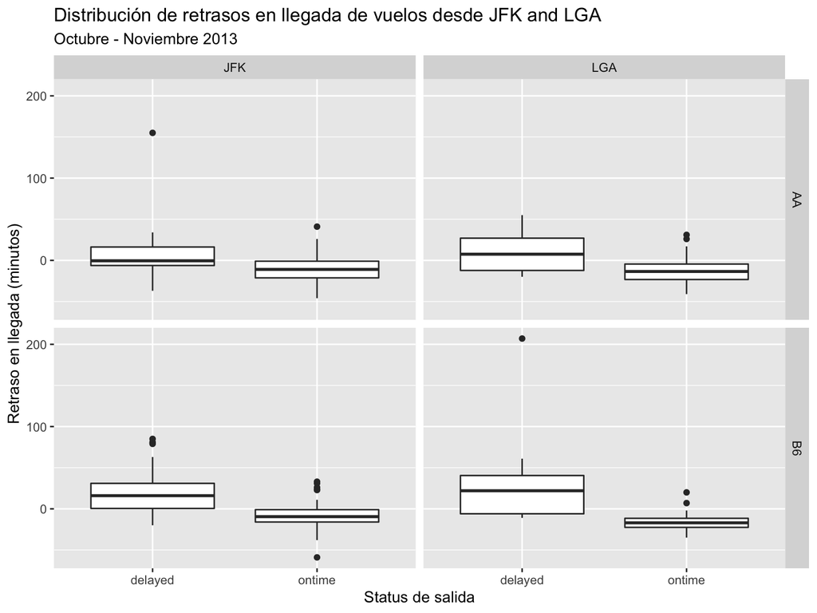

```r
flights_small %>%
  filter(carrier %in% c("AA", "B6"),
         month %in% c(10,11),
         origin %in% c("JFK", "LGA") )%>%
  filter(!is.na(arr_delay), !is.na(dep_delay)) %>%
  mutate(dep_status = ifelse(dep_delay <= 0, "ontime", "delayed")) %>%
  ggplot(., aes(x = dep_status, y = arr_delay)) +
  geom_boxplot() +
  facet_grid(carrier ~ origin) +
  labs(x = "Status de salida", y = "Retraso en llegada (minutos)") +
  ggtitle("Distribución de retrasos en llegada de vuelos desde JFK and LGA",
          subtitle = "Octubre - Noviembre 2013")
```